# explaratory analysis - no of visits

# Health across the different regions(Region Analysis)

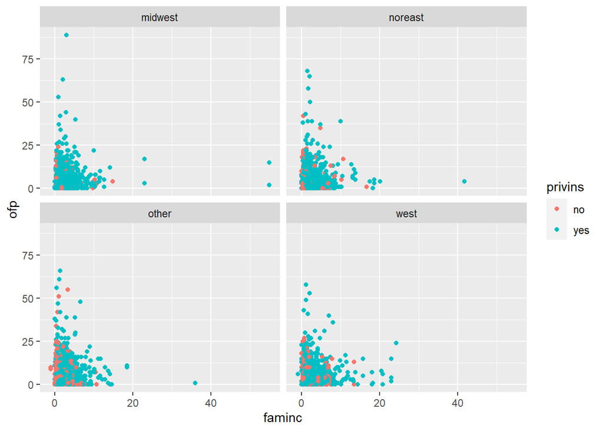

```r
data2 %>%
    ggplot(aes(x = faminc, y = ofp, colour = privins)) + geom_point() + facet_wrap(~region)
```

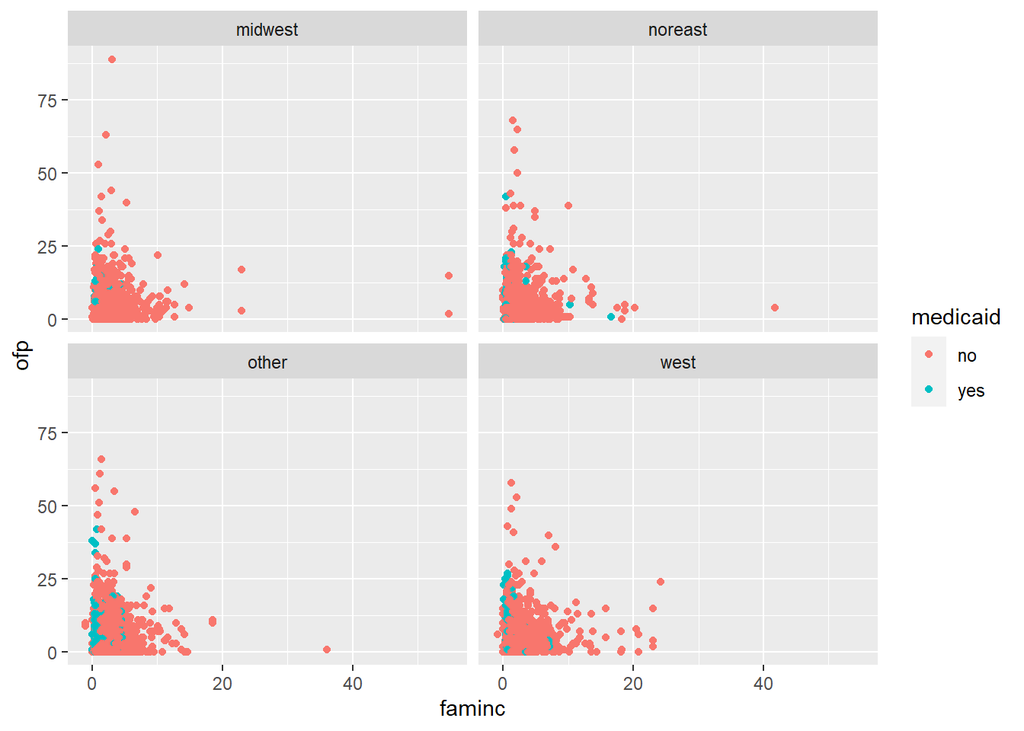

```r
data2 %>%
    ggplot(aes(x = faminc, y = ofp, colour = medicaid)) + geom_point() + facet_wrap(~region)
```

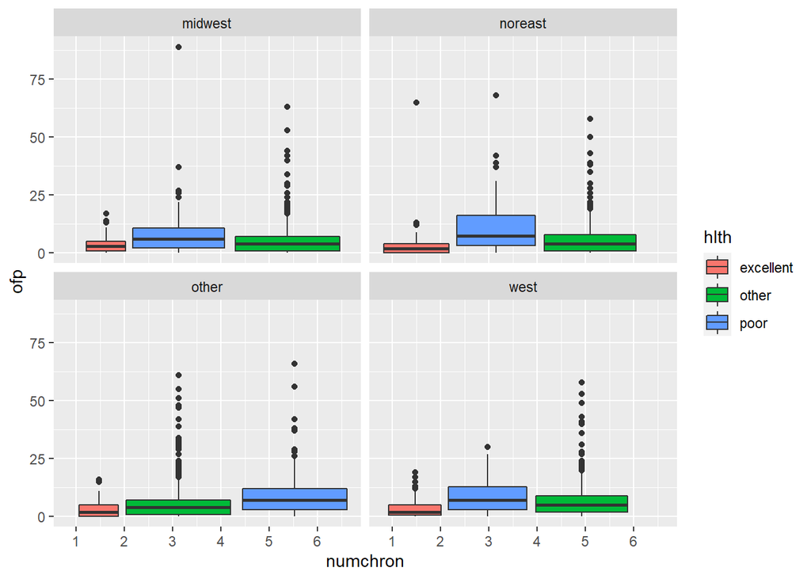

```r
data2 %>%
    ggplot(aes(x = numchron, y = ofp, fill = hlth)) + geom_boxplot() + facet_wrap(~region)
```

## Observation

Most individuals in all the regions see a doctor between 0 and 25 times in a year regardless of the income earned. The ill individuals(poor health) seem to be visiting the doctor more frequently compared to the healthy individuals in all the regions and they have an average of 2-4 chronic conditions.

In terms of insurance coverage, those with a low income seem to be insured by medicaid while the rest are insured by private insurance.

# Health across demographics.

## Age

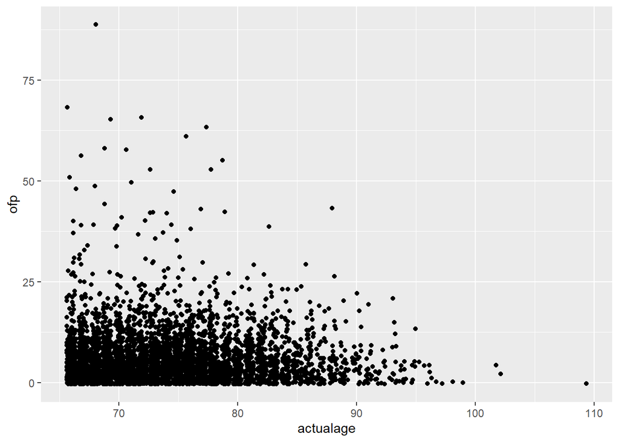

```r
data2 %>%
    ggplot(aes(x = actualage, y = ofp)) + geom_jitter()
```

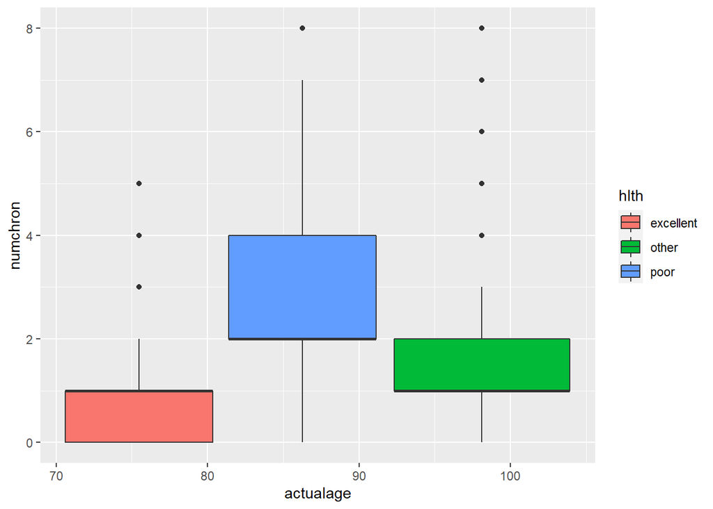

```r
data2 %>%
    ggplot(aes(x = actualage, y = numchron, fill = hlth)) + geom_boxplot()
```

## Sex

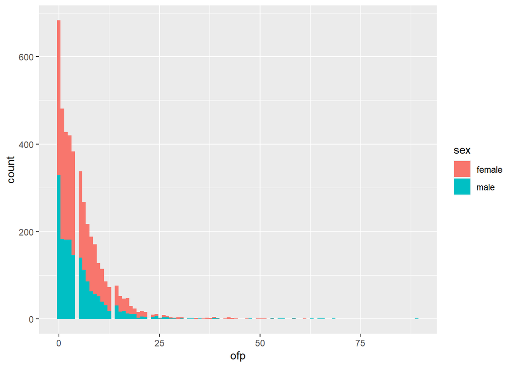

```r
data2 %>%
    ggplot(aes(x = ofp)) + geom_histogram(aes(fill = sex), bins = 100)
```

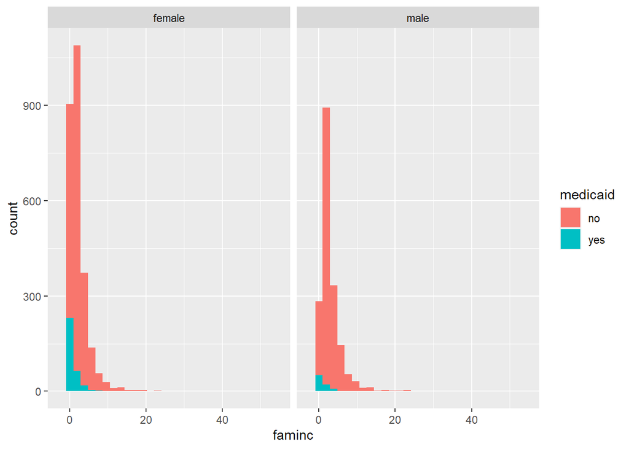

```r
data2 %>%
    ggplot(aes(x = faminc)) + geom_histogram(aes(fill = medicaid), bins = 30) + facet_wrap(~sex)
```

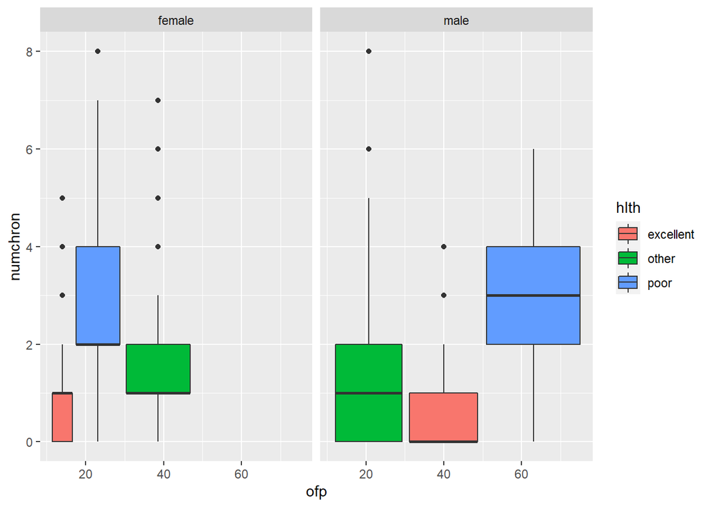

```r
data2 %>%
    ggplot(aes(x = ofp, y = numchron, fill = hlth)) + geom_boxplot() + facet_wrap(~sex)
```